# Análisis de la Temperatura en Málaga (1960-2023)

### PREGUNTA 3: Valida el modelo utilizando las herramientas adecuadas e indica cual es la comprobacion mas importante.

```
##
##  Shapiro-Wilk normality test
##
## data:  residuos
## W = 0.9982, p-value = 0.6246
```

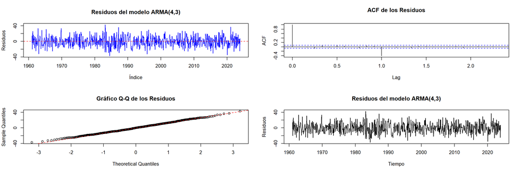

```
##
##  Box-Ljung test
##
## data:  residuos
## X-squared = 151.84, df = 20, p-value < 2.2e-16
```

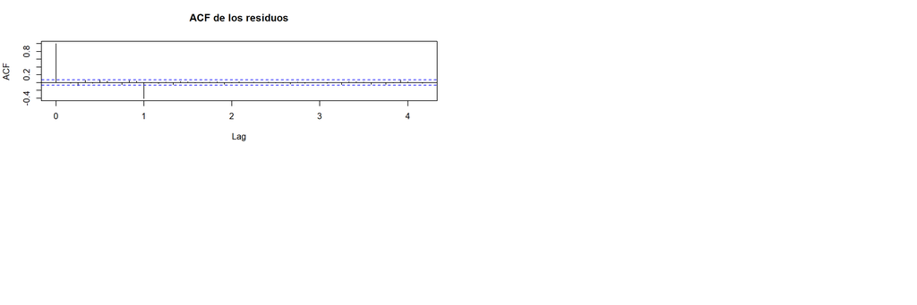

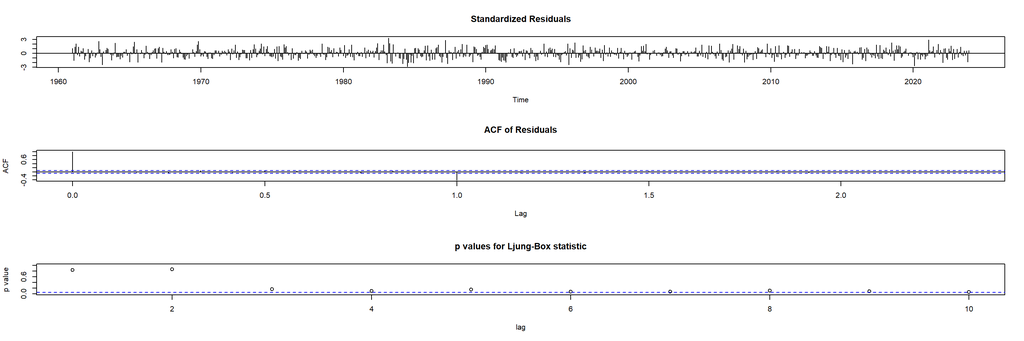

Los resultados obtenidos reflejan dos aspectos importantes en la validación del modelo ARMA(4,3). Primero, la prueba de Ljung-Box arroja un estadístico X-squared = 151.84, con 20 grados de libertad y un p-valor menor a 2.2e-16. Este p-valor extremadamente bajo indica que los residuos no son independientes, lo que sugiere que el modelo ARMA(4,3) no ha capturado toda la estructura de autocorrelación presente en los datos. Esto implica que los residuos presentan patrones que deberían haber sido eliminados si el modelo fuese adecuado.

Por otro lado, la prueba de normalidad de Shapiro-Wilk muestra un estadístico W = 0.9982 y un p-valor de 0.6246. Este p-valor alto indica que no se rechaza la hipótesis nula de que los residuos siguen una distribución normal. Por lo tanto, en este aspecto, el modelo parece adecuado, ya que produce residuos que se distribuyen de manera aproximadamente normal.

En conclusión, aunque los residuos cumplen con la condición de normalidad, no cumplen con la independencia requerida según la prueba de Ljung-Box. Este hallazgo sugiere que el modelo ARMA(4,3) no es óptimo para los datos analizados. En este caso, podría considerarse la utilización de otros enfoques, como modelos SARIMA, que permiten ajustar tanto la estacionalidad como la estructura temporal de la serie.